# Code Compendium: Loudon et al. Manuscript

## Rationale

This document complements the manuscript, “Healing Hanuman’s Army: Veterinary Care as a Core Component of One Health Principles in a Southeast Asian Monkey Forest” written by Loudon et al and in preparation for **Animals**.

Assuming a working version of the R programming language, the code that follows will replicate all steps necessary to recreate the results in the paper. Questions about access to the necessary data files should be directed to James Loudon, PhD, East Carolina University. Questions about the statistical analyses should be directed to Christopher Wolfe, PhD, East Carolina University.

## Statistical Analyses

The remainder of this document can be divided into 3 broad sections: 1) Initial Data Preparation, 2) Model Fit, Validation, and Selection, and 3) Manuscript Results.

### Initial Data Preparation

Here we load in the requisite packages and organize the data for analysis. We make sure all of our categories are represented as factors and create a new colomun entitled “symptom”. This new column is the variable of interest ($y$) and encapsulates the binary or dichotomous nature of the possible outcomes for each macaque that is seen at the clinic: Injury or Death.

#### Load Requisite Packages

```r
library(tidyverse) ## Data Wrangling and Organization
library(magrittr) ## Additional tools for Data Wrangling
library(brms) ## Bayesian Modeling with Hamiltonian Monte Carlo (Stan)
```

```r
library(bayesplot)
library(tidybayes)
library(broom)
library(broom.mixed)
library(visibly)
color_scheme_set("red")
cmdstanr::set_cmdstan_path("C:/Users/chris/Documents_Local/cmdstan-2.33.1")
```

#### Import Data and Wrangle for Clarity

```r
dat <- read.csv("macaque_injury_raw.csv") ## Import Data
colnames(dat) <- c("year","age", "age_class", "sex", "group", "fight", "anthropogenic","injury", "death") ## Change column names for clarity
```

```r
## Clean up the data file and make all predictors factors instead of characters
dat %<>% select(year, age_class, sex, group, fight, anthropogenic, death) %>% mutate(year = factor(year), age_class = factor(age_class, levels = c("0-1 year ", "1-4 years", "5-9 years", "10-15 years", "16+ years")), sex = if_else(sex == "F",0,1), sex = factor(sex), group = factor(group), fight = if_else(fight == "no",0,1), fight = factor(fight), anthropogenic = if_else(anthropogenic=="natural",0,1), anthropogenic = factor(anthropogenic), symptom = if_else(death=="no",0,1))

head(dat,3)
```

```
##   year   age_class sex   group fight anthropogenic death symptom
## 1 2015   5-9 years   0 Central     0             1    no       0
## 2 2015   0-1 year    1    East     0             1    no       0
## 3 2015 10-15 years   1 Central     0             1    no       0
```

### Model Fit, Validation, and Selection

Here we fit 3 model constructions. The general construction of all models is as follows: $y \sim Bernoulli(\theta)$ where $y$ is the occurrence of injury or death and $\theta$ is the probability of dying. Each code chunk shows model fit, a summary of the output, and stores a `loo` object to be used for model comparison below.

#### Model 1: Baseline Model - Intercept Only

$\mu_{i} = X\beta + \epsilon$, where $\beta_0$ is an intercept sampled as part of the model. $\epsilon$ is the error term. Here, I exclude all population-level parameters.

```r
base <- brm(formula = symptom ~ 1, data=dat, family = bernoulli(link = "logit"), chains = 4, cores=4)
summary(base)
```

```
##  Family: bernoulli
##   Links: mu = logit
## Formula: symptom ~ 1
##    Data: dat (Number of observations: 275)
##   Draws: 4 chains, each with iter = 2000; warmup = 1000; thin = 1;
##          total post-warmup draws = 4000
##
## Population-Level Effects:
##           Estimate Est.Error l-95% CI u-95% CI Rhat Bulk_ESS Tail_ESS
## Intercept    -0.17      0.12    -0.40     0.08 1.00     1525     1826
##
## Draws were sampled using sampling(NUTS). For each parameter, Bulk_ESS
## and Tail_ESS are effective sample size measures, and Rhat is the potential
## scale reduction factor on split chains (at convergence, Rhat = 1).
```

```r
loo_base <- loo(base)
loo_base
```

```
##
## Computed from 4000 by 275 log-likelihood matrix
##
##          Estimate  SE
## elpd_loo   -190.7 1.4
## p_loo         1.0 0.0
## looic       381.4 2.8
## ------
## Monte Carlo SE of elpd_loo is 0.0.
##
## All Pareto k estimates are good (k < 0.5).
## See help('pareto-k-diagnostic') for details.
```

#### Model 2: Fixed Effects Only

$\mu_{i} = X\beta + \epsilon$, where $\beta$ is a $p-by-1$ vector of population level effects including age class, sex, group, fighting, anthropogenic, and year. $\epsilon$ is the error term.

```r
fixed <- brm(formula = symptom ~ 1 + age_class + sex + group + fight + anthropogenic + year, data=dat, family = bernoulli(link = "logit"), chains = 4, cores=4)
summary(fixed)
```

```
##  Family: bernoulli
##   Links: mu = logit
## Formula: symptom ~ 1 + age_class + sex + group + fight + anthropogenic + year
##    Data: dat (Number of observations: 275)
##   Draws: 4 chains, each with iter = 2000; warmup = 1000; thin = 1;
##          total post-warmup draws = 4000
##
## Population-Level Effects:
##                     Estimate Est.Error l-95% CI u-95% CI Rhat Bulk_ESS Tail_ESS
## Intercept               3.04      0.73     1.62     4.50 1.00     1949     2103
## age_class1M4years      -1.59      0.52    -2.63    -0.58 1.00     2171     2479
## age_class5M9years      -2.14      0.51    -3.17    -1.18 1.00     2273     2602
## age_class10M15years    -2.63      0.54    -3.72    -1.63 1.00     2439     2407
## age_class16Pyears      -2.15      1.66    -5.87     0.85 1.00     4139     2256
## sex1                   -0.80      0.31    -1.40    -0.19 1.00     4205     2925
## groupCentral           -0.56      0.46    -1.47     0.32 1.00     2868     2598
## groupEast              -0.59      0.64    -1.85     0.65 1.00     2855     2711
## groupMichelin           0.26      0.53    -0.79     1.30 1.00     3300     2938
## groupNewForest         -0.19      0.81    -1.81     1.45 1.00     3849     2875
## groupTemple            -0.62      0.42    -1.45     0.20 1.00     2647     2512
## fight1                 -1.07      0.75    -2.62     0.34 1.00     4142     2990
## anthropogenic1          0.81      0.40     0.02     1.62 1.00     4232     3105
## year2016               -0.89      0.46    -1.78     0.00 1.00     2874     2867
## year2017               -0.21      0.50    -1.21     0.76 1.00     3020     2733
## year2018               -0.74      0.52    -1.82     0.26 1.00     2439     2833
##
## Draws were sampled using sampling(NUTS). For each parameter, Bulk_ESS
## and Tail_ESS are effective sample size measures, and Rhat is the potential
## scale reduction factor on split chains (at convergence, Rhat = 1).
```

```r
loo_fixed <- loo(fixed)
loo_fixed
```

```
##
## Computed from 4000 by 275 log-likelihood matrix
##
##          Estimate   SE
## elpd_loo   -180.5  9.1
## p_loo        20.3  3.1
## looic       360.9 18.2
## ------
## Monte Carlo SE of elpd_loo is NA.
##
## Pareto k diagnostic values:
##                          Count Pct.    Min. n_eff
## (-Inf, 0.5]   (good)     272   98.9%   1722
##  (0.5, 0.7]   (ok)         2    0.7%   1213
##    (0.7, 1]   (bad)        1    0.4%   35
##    (1, Inf)   (very bad)   0    0.0%   <NA>
## See help('pareto-k-diagnostic') for details.
```

#### Model 3: Multilevel Model

$\mu_{i} = X\beta + Zb + \epsilon$, where $\beta$ is a $p-by-1$ vector of population level effects including age class, sex, group, fighting, anthropogenic, and year, $Z$ is $n-by-1$ random effects design matrix such that the probability of death is the result of group level variation across social groups and study year. $\epsilon$ is the error term.

```r
mixed <- brm(formula = symptom ~ 1 + age_class + sex + fight + anthropogenic + year +(1 + year|group), data=dat, family = bernoulli(link = "logit"), chains = 4, cores=4, prior = c(set_prior("normal(1,1)", class = "Intercept"),set_prior("normal(0,1)", class = "b"), set_prior("normal(0,1)", class = "sd")), control = list(adapt_delta = 0.95))
summary(mixed)
```

```
##  Family: bernoulli
##   Links: mu = logit
## Formula: symptom ~ 1 + age_class + sex + fight + anthropogenic + year + (1 + year | group)
##    Data: dat (Number of observations: 275)
##   Draws: 4 chains, each with iter = 2000; warmup = 1000; thin = 1;
##          total post-warmup draws = 4000
##
## Group-Level Effects:
## ~group (Number of levels: 6)
##                         Estimate Est.Error l-95% CI u-95% CI Rhat Bulk_ESS
## sd(Intercept)               0.29      0.24     0.01     0.86 1.00     2129
## sd(year2016)                0.35      0.29     0.01     1.11 1.00     2800
## sd(year2017)                0.60      0.43     0.03     1.60 1.00     2322
## sd(year2018)                0.40      0.32     0.02     1.20 1.00     2899
## cor(Intercept,year2016)    -0.08      0.46    -0.85     0.80 1.00     5956
## cor(Intercept,year2017)     0.02      0.44    -0.82     0.80 1.00     3873
## cor(year2016,year2017)      0.01      0.46    -0.80     0.84 1.00     3844
## cor(Intercept,year2018)    -0.03      0.45    -0.82     0.80 1.00     5803
## cor(year2016,year2018)      0.03      0.45    -0.80     0.81 1.00     3882
## cor(year2017,year2018)      0.07      0.44    -0.76     0.84 1.00     3596
##                         Tail_ESS
## sd(Intercept)               2413
## sd(year2016)                1727
## sd(year2017)                1692
## sd(year2018)                2309
## cor(Intercept,year2016)     2890
## cor(Intercept,year2017)     2891
## cor(year2016,year2017)      3300
## cor(Intercept,year2018)     2807
## cor(year2016,year2018)      3000
## cor(year2017,year2018)      3562
##
## Population-Level Effects:
##                     Estimate Est.Error l-95% CI u-95% CI Rhat Bulk_ESS Tail_ESS
## Intercept               1.61      0.49     0.68     2.60 1.00     3088     2464
## age_class1M4years      -0.81      0.39    -1.60    -0.07 1.00     3356     3009
## age_class5M9years      -1.35      0.37    -2.10    -0.64 1.00     3469     3094
## age_class10M15years    -1.77      0.41    -2.56    -0.99 1.00     3573     2977
## age_class16Pyears      -0.49      0.77    -1.99     0.99 1.00     6686     2867
## sex1                   -0.67      0.28    -1.24    -0.12 1.00     7742     2775
## fight1                 -0.76      0.53    -1.82     0.25 1.00     6305     2965
## anthropogenic1          0.76      0.37     0.06     1.52 1.00     7085     2761
## year2016               -0.53      0.39    -1.31     0.25 1.00     3835     3148
## year2017                0.16      0.47    -0.74     1.13 1.00     3615     3192
## year2018               -0.22      0.44    -1.08     0.67 1.00     4004     3104
##
## Draws were sampled using sampling(NUTS). For each parameter, Bulk_ESS
## and Tail_ESS are effective sample size measures, and Rhat is the potential
## scale reduction factor on split chains (at convergence, Rhat = 1).
```

```r
loo_mixed <- loo(mixed)
loo_mixed
```

```
##
## Computed from 4000 by 275 log-likelihood matrix
##
##          Estimate   SE
## elpd_loo   -175.8  6.1
## p_loo        14.2  0.8
## looic       351.7 12.3
## ------
## Monte Carlo SE of elpd_loo is 0.1.
##
## All Pareto k estimates are good (k < 0.5).
## See help('pareto-k-diagnostic') for details.
```

#### Model Selection

Here we use the three models fit above and determine the best-fitting model using ELPD from the `loo` package.

```r
loo_compare(loo_base, loo_fixed, loo_mixed)
```

```
##       elpd_diff se_diff
## mixed   0.0       0.0
## fixed  -4.6       4.1
## base  -14.8       6.1
```

The results above suggest the hierarchical or mixed effects model is best. That is to say, the occurrence of an injury or death at the Ubud National Forest is the results of population-level effects including sex, age class, whether one was fighting or not, and whether the reason for the vet visit was anthropogenic or natural in origin. Further, these effects vary across each of the 6 groups over all 4 years of the study project.

The remainder of this document will assume the mixed effects as best and base all additional analyses from this model.

#### Model Validation - Posterior Predictive Check

Here, I use the model to predict the outcomes across each of the predictors (fixed and random effects). Note, in the age class data the predictive line does encapsulate the true prediction it is just inside the 95th highest posterior density. The reason for this “outlier” is the lack of data in this age class across the sample - only 3 total and 2 were injured 1 was dead.

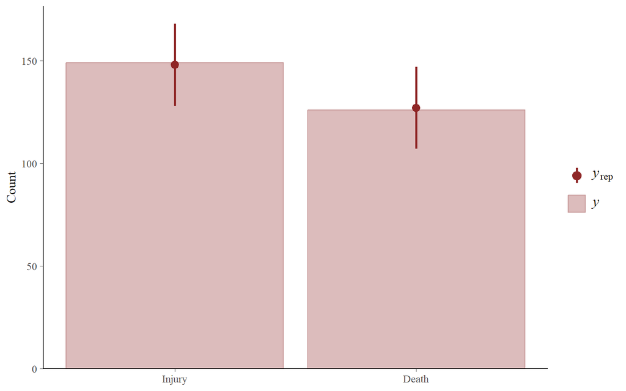

```r
## ungrouped
ppc_bars(y = dat$symptom,yrep = posterior_predict(mixed, ndraws=500), prob = 0.95) + scale_x_continuous(breaks = c(0:1), labels = paste0(c("Injury", "Death")))
```

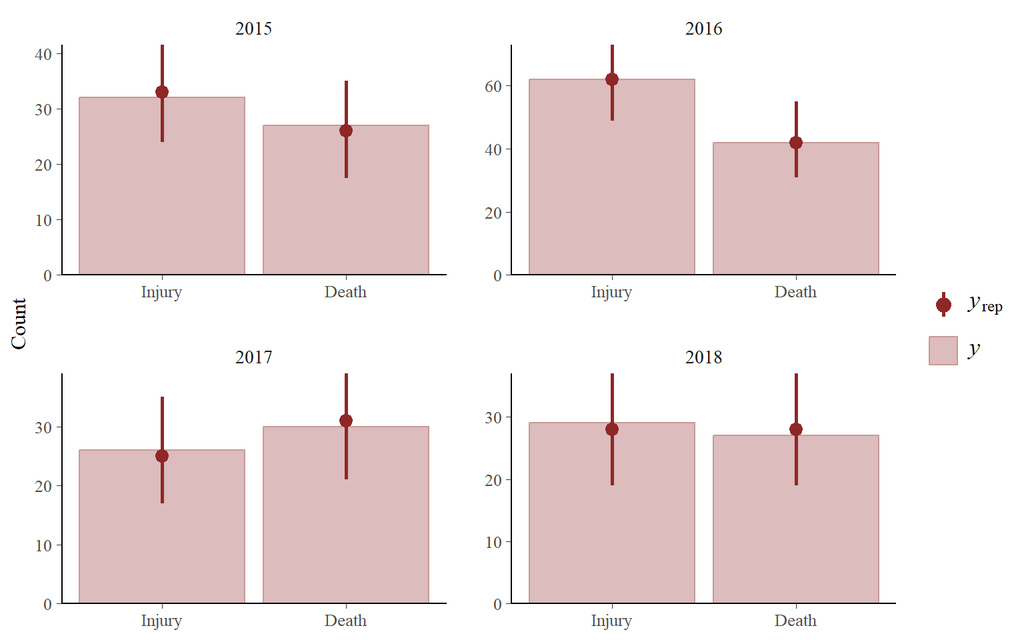

```r
## year
ppc_bars_grouped(y = dat$symptom,yrep = posterior_predict(mixed, ndraws=500), prob = 0.95, group = dat$year, facet_args = list(scales = "free")) + scale_x_continuous(breaks = c(0:1), labels = paste0(c("Injury", "Death")))
```

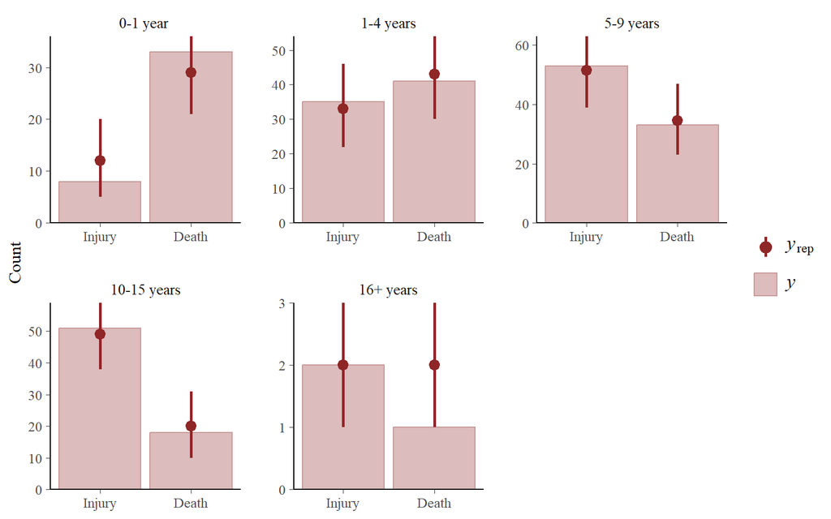

```r
## age class
ppc_bars_grouped(y = dat$symptom,yrep = posterior_predict(mixed, ndraws=500), prob = 0.95, group = dat$age_class, facet_args = list(scales = "free")) + scale_x_continuous(breaks = c(0:1), labels = paste0(c("Injury", "Death")))
```

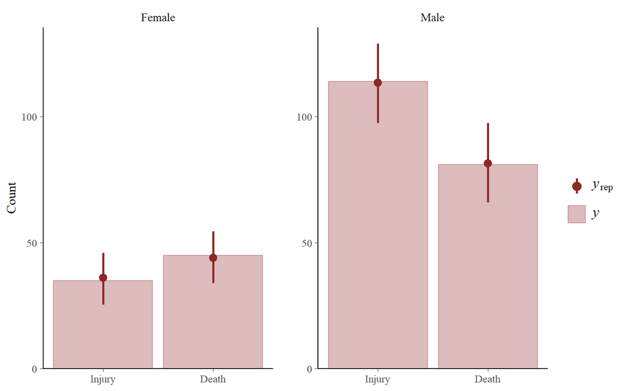

```r
## sex
ppc_bars_grouped(y = dat$symptom,yrep = posterior_predict(mixed, ndraws=500), prob = 0.95, group = dat$sex) + scale_x_continuous(breaks = c(0:1), labels = paste0(c("Injury", "Death"))) + facet_wrap("group", labeller = as_labeller(c("0" = "Female", "1" = "Male")), scales = "free")
```

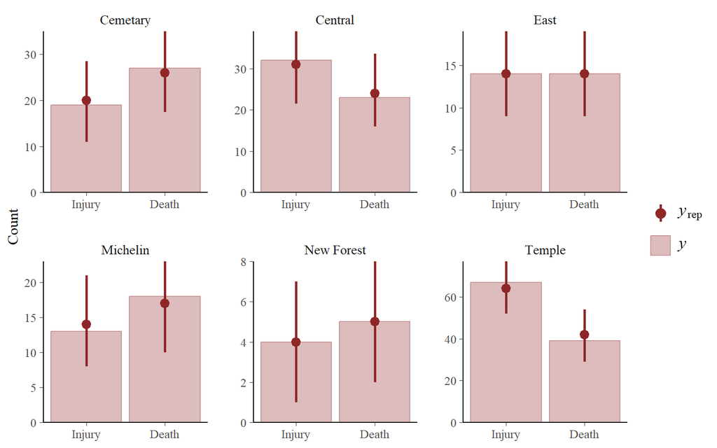

```r
## group
ppc_bars_grouped(y = dat$symptom,yrep = posterior_predict(mixed, ndraws=500), prob = 0.95, group = dat$group, facet_args = list(scales = "free")) + scale_x_continuous(breaks = c(0:1), labels = paste0(c("Injury", "Death")))
```

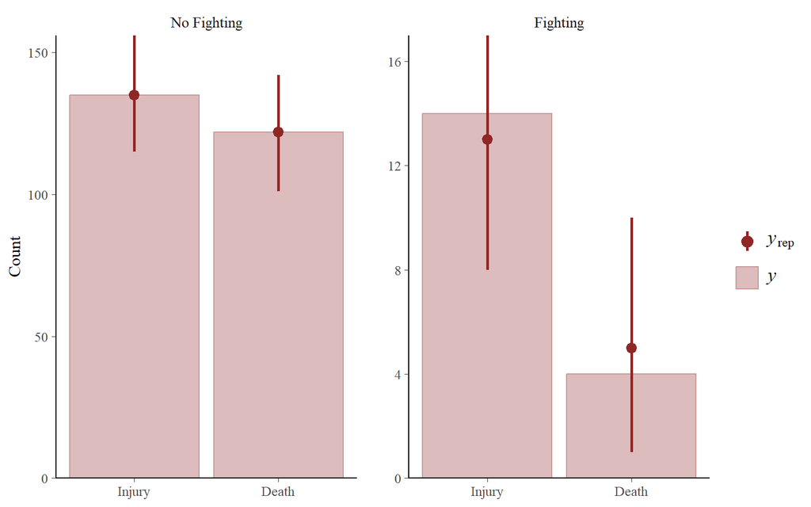

```r
## fight
ppc_bars_grouped(y = dat$symptom,yrep = posterior_predict(mixed, ndraws=500), prob = 0.95, group = dat$fight, facet_args = list(scales = "free")) + scale_x_continuous(breaks = c(0:1), labels = paste0(c("Injury", "Death"))) + facet_wrap("group", labeller = as_labeller(c("0" = "No Fighting", "1" = "Fighting")), scales = "free")
```

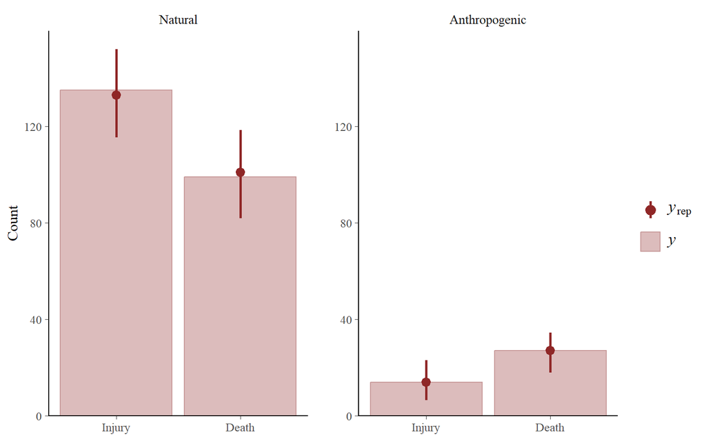

```r
## anthropogenic
ppc_bars_grouped(y = dat$symptom,yrep = posterior_predict(mixed, ndraws=500), prob = 0.95, group = dat$anthropogenic) + scale_x_continuous(breaks = c(0:1), labels = paste0(c("Injury", "Death"))) + facet_wrap("group", labeller = as_labeller(c("0" = "Natural", "1" = "Anthropogenic")), scales = "free")
```

## Manuscript Results

The above code suggests we have a well-formed description of the data generating process where the probability of injury or death is the result of several population- and and group-level effects. The `loo` results and the posterior predictive check suggests the model does a good job recovering each set of relationships.

The remainder of this document provides a broad set of results to highlight the various relationships present across the data.

### General Model Results

#### Full Model Coefficients

Here I again provide the general summary of all parameters sampled in the model. I also include the densities and traceplots of each for completeness - these show the estimate, variation in the estimate, and provide validity for each parameter. Note, these are on the log scale. Remember this is a logistic regression model where 0 = injury and 1 = death. All values relate to the probability of being found dead with the inverse being the probability of being found injured.

Group Effects: sd() = standard deviation in the group level terms. The higher the value, the more variation between each social group over each year. 2017 shows the largest levels of variation between groups. cor() = the relationship between year and group on the scale -1 to 1. In general, there is little to no yearly trend between the groups.

Population Effects: Each of these coefficients are on the log scale. A negative number assumes a decrease in log odds while a positive number assumes an increase in log odds. All numbers are in the context of the reference category. For instance, the `sex1` covariates relate to the odds of male macaques being found dead. Because this is a logistic regression model, if the covariate assumes a decrease in the odds of death, than the opposite is also true - an increase in the odds of being injured.

```r
summary(mixed)
```

```
##  Family: bernoulli
##   Links: mu = logit
## Formula: symptom ~ 1 + age_class + sex + fight + anthropogenic + year + (1 + year | group)
##    Data: dat (Number of observations: 275)
##   Draws: 4 chains, each with iter = 2000; warmup = 1000; thin = 1;
##          total post-warmup draws = 4000
##
## Group-Level Effects:
## ~group (Number of levels: 6)
##                         Estimate Est.Error l-95% CI u-95% CI Rhat Bulk_ESS
## sd(Intercept)               0.29      0.24     0.01     0.86 1.00     2129
## sd(year2016)                0.35      0.29     0.01     1.11 1.00     2800
## sd(year2017)                0.60      0.43     0.03     1.60 1.00     2322
## sd(year2018)                0.40      0.32     0.02     1.20 1.00     2899
## cor(Intercept,year2016)    -0.08      0.46    -0.85     0.80 1.00     5956
## cor(Intercept,year2017)     0.02      0.44    -0.82     0.80 1.00     3873
## cor(year2016,year2017)      0.01      0.46    -0.80     0.84 1.00     3844
## cor(Intercept,year2018)    -0.03      0.45    -0.82     0.80 1.00     5803
## cor(year2016,year2018)      0.03      0.45    -0.80     0.81 1.00     3882
## cor(year2017,year2018)      0.07      0.44    -0.76     0.84 1.00     3596
##                         Tail_ESS
## sd(Intercept)               2413
## sd(year2016)                1727
## sd(year2017)                1692
## sd(year2018)                2309
## cor(Intercept,year2016)     2890
## cor(Intercept,year2017)     2891
## cor(year2016,year2017)      3300
## cor(Intercept,year2018)     2807
## cor(year2016,year2018)      3000
## cor(year2017,year2018)      3562
##
## Population-Level Effects:
##                     Estimate Est.Error l-95% CI u-95% CI Rhat Bulk_ESS Tail_ESS
## Intercept               1.61      0.49     0.68     2.60 1.00     3088     2464
## age_class1M4years      -0.81      0.39    -1.60    -0.07 1.00     3356     3009
## age_class5M9years      -1.35      0.37    -2.10    -0.64 1.00     3469     3094
## age_class10M15years    -1.77      0.41    -2.56    -0.99 1.00     3573     2977
## age_class16Pyears      -0.49      0.77    -1.99     0.99 1.00     6686     2867
## sex1                   -0.67      0.28    -1.24    -0.12 1.00     7742     2775
## fight1                 -0.76      0.53    -1.82     0.25 1.00     6305     2965
## anthropogenic1          0.76      0.37     0.06     1.52 1.00     7085     2761
## year2016               -0.53      0.39    -1.31     0.25 1.00     3835     3148
## year2017                0.16      0.47    -0.74     1.13 1.00     3615     3192
## year2018               -0.22      0.44    -1.08     0.67 1.00     4004     3104
##
## Draws were sampled using sampling(NUTS). For each parameter, Bulk_ESS
## and Tail_ESS are effective sample size measures, and Rhat is the potential
## scale reduction factor on split chains (at convergence, Rhat = 1).
```

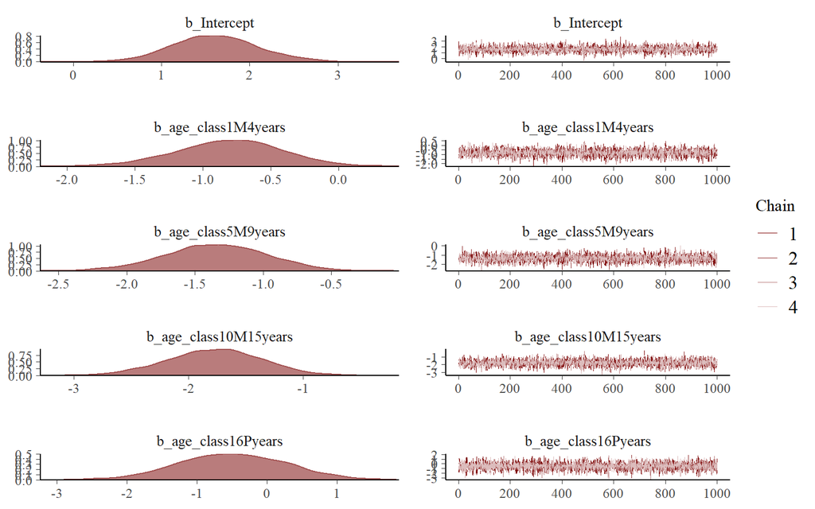

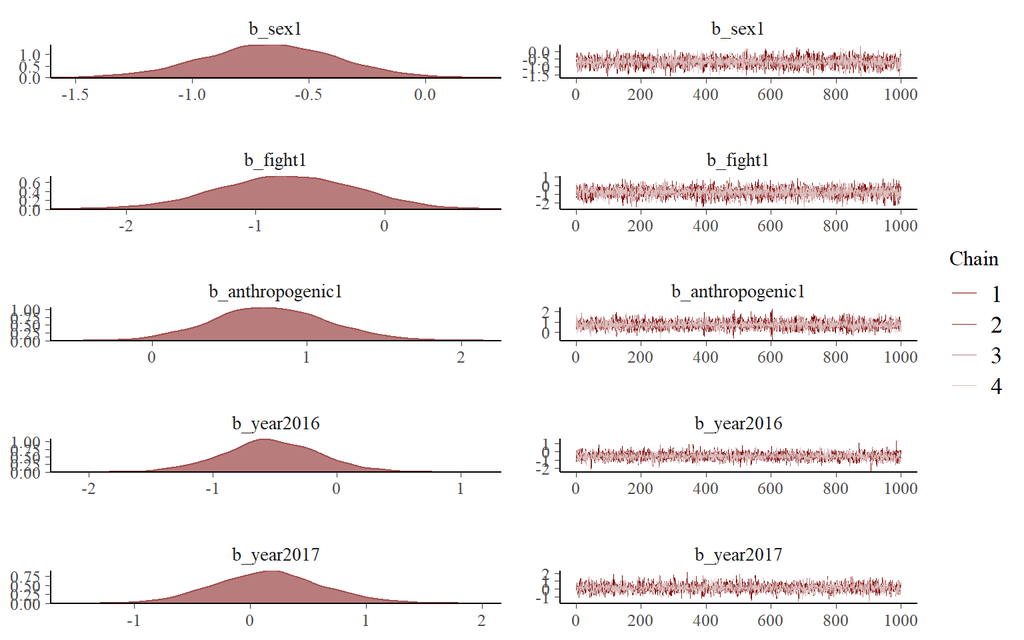

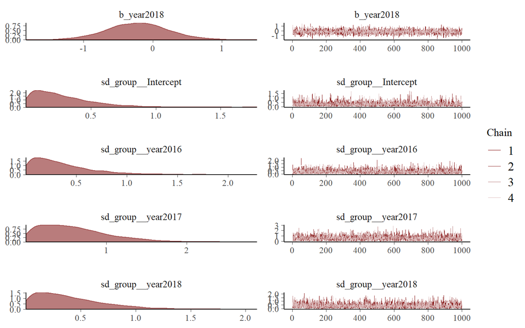

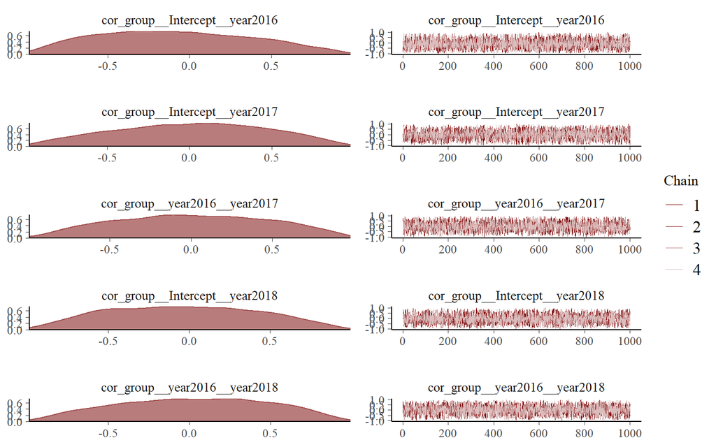

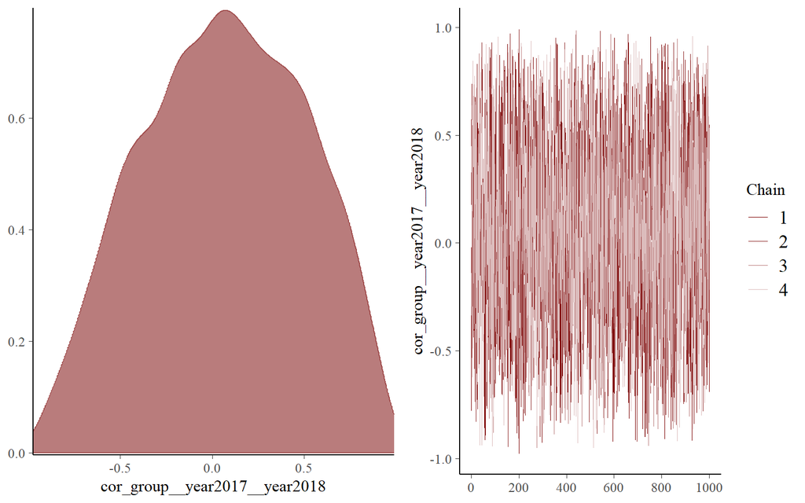

```r
plot(mixed)
```

#### Effects

The above information is helpful, but the log scale is difficult to interpret. Here I exponentiate the results to put them on the probability scale. This gives us the traditional interpretation of the logistic regression: an odds ratio. Any value below 1 is a decrease in odds and any value above 1 is an increase in odds. I will present both the odds ratio (OR) associated with the odds of being found dead and the inverse of the odds ratio 1/OR associated with the odds of being found injured. Again, all comparisons are made in reference to the broader category of reference.

```r
func <- function(x){
  1/exp(x)
}
```

##### Population Level or Fixed Effects

```r
fixef(mixed) %>% exp() %>% round(digits = 2)
```

```
##                     Estimate Est.Error Q2.5 Q97.5
## Intercept               5.01      1.63 1.98 13.48
## age_class1M4years       0.45      1.48 0.20  0.94
## age_class5M9years       0.26      1.45 0.12  0.53
## age_class10M15years     0.17      1.50 0.08  0.37
## age_class16Pyears       0.61      2.16 0.14  2.70
## sex1                    0.51      1.33 0.29  0.88
## fight1                  0.47      1.70 0.16  1.29
## anthropogenic1          2.15      1.45 1.06  4.56
## year2016                0.59      1.48 0.27  1.28
## year2017                1.17      1.61 0.47  3.08
## year2018                0.81      1.56 0.34  1.96
```

```r
fixef(mixed) %>% func() %>% round(digits = 2)
```

```
##                     Estimate Est.Error  Q2.5 Q97.5
## Intercept               0.20      0.61  0.51  0.07
## age_class1M4years       2.24      0.68  4.97  1.07
## age_class5M9years       3.84      0.69  8.15  1.89
## age_class10M15years     5.88      0.67 12.98  2.70
## age_class16Pyears       1.64      0.46  7.34  0.37
## sex1                    1.95      0.75  3.44  1.13
## fight1                  2.13      0.59  6.15  0.78
## anthropogenic1          0.47      0.69  0.94  0.22
## year2016                1.70      0.68  3.70  0.78
## year2017                0.85      0.62  2.11  0.32
## year2018                1.24      0.64  2.93  0.51
```

**Interpretation**

1. 10 to 15 year olds are most likely to be injured, while 0-1 year olds are most likely to be found dead
2. Females are more likely to be found dead, while males are more likely to be injured.
3. Fighting leads to more injuries as compared to deaths
4. Anthropogenic factors are more likely to cause death, while natural causes lead to injury.
5. 2017 saw the greatest odds of death, while 2016 led to the greatest odds of injury.

##### Group level or random effects

Each of the effects described above relates to an overall population-level effect. In other words, regardless of year or group, there are differences based on sex, age class, fighting or not, and natural vs. anthropogenic.

However, there is a time component and group level of variation. Perhaps the probability of death (or injury) varies based on one’s social group (and resulting access to humans) and each year.

```r
rans <- ranef(mixed)
y2015 <- rans$group[,,1][,c(1,3:4)]
y2016 <- rans$group[,,2][,c(1,3:4)]
y2017 <- rans$group[,,3][,c(1,3:4)]
y2018 <- rans$group[,,4][,c(1,3:4)]

grps <- rbind(y2015, y2016, y2017, y2018)
grps <- as.data.frame(grps)
grps %<>% func() %>% round(digits=2)
grps$year <- c(rep(c("2015","2016","2017","2018"), each=6))
grps$group <- c(rep(c("Cemetery","Central","East","Michelin","New Forest","Temple"), times=1))

rownames(grps) <- c(1:24)

grps
```

```
##    Estimate Q2.5 Q97.5 year      group
## 1      0.94 1.56  0.52 2015   Cemetery
## 2      1.11 2.14  0.73 2015    Central
## 3      1.00 1.89  0.56 2015       East
## 4      0.93 1.55  0.46 2015   Michelin
## 5      0.99 1.88  0.49 2015 New Forest
## 6      1.13 2.05  0.75 2015     Temple
## 7      0.92 1.67  0.43 2016   Cemetery
## 8      0.95 1.78  0.45 2016    Central
## 9      1.07 2.53  0.53 2016       East
## 10     1.07 2.64  0.53 2016   Michelin
## 11     1.11 2.99  0.55 2016 New Forest
## 12     1.06 2.20  0.57 2016     Temple
## 13     0.87 2.36  0.26 2017   Cemetery
## 14     1.15 3.23  0.50 2017    Central
## 15     1.22 6.58  0.37 2017       East
## 16     0.73 1.63  0.21 2017   Michelin
## 17     0.77 2.26  0.13 2017 New Forest
## 18     1.41 4.70  0.64 2017     Temple
## 19     0.96 2.17  0.39 2018   Cemetery
## 20     1.07 2.68  0.51 2018    Central
## 21     1.03 2.88  0.37 2018       East
## 22     0.96 2.14  0.41 2018   Michelin
## 23     0.98 2.44  0.37 2018 New Forest
## 24     1.16 2.80  0.62 2018     Temple
```

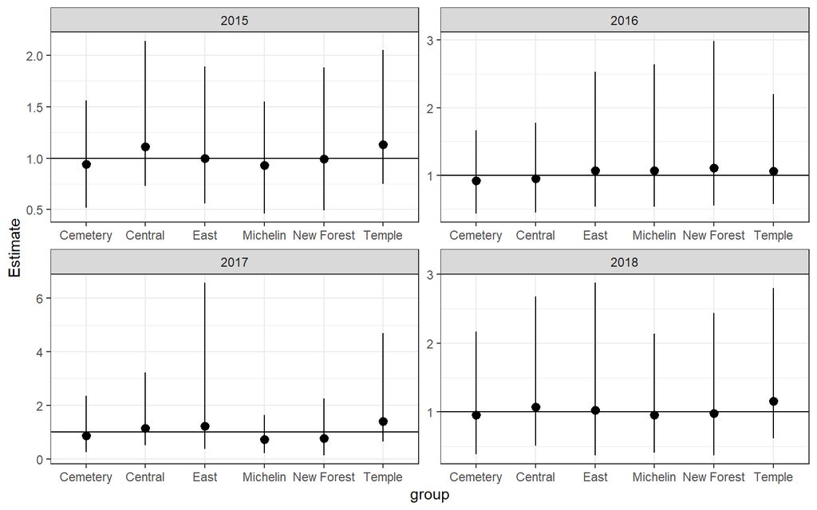

```r
grps %>% ggplot() + geom_pointrange(aes(x = group,y=Estimate,ymin = Q2.5, ymax=Q97.5)) + facet_wrap(vars(year), scales = "free") + geom_hline(yintercept = 1) +theme_bw()
```

## Summary

In general, the results suggest that the veterinary caseload at the Ubud Monkey Forest as it relates to morbidity and/or mortality is influenced by the sex of the macaque, age class, whether they fought or not, whether the reason was anthropogenic or natural, and such events vary across groups for each study year.